# student_survey_analysis

Kevin Gilds

2016-06-10

```r
setwd("C:/Users/kevin/Dropbox/GetReal/Analyis_data")

getReal_2013 <-dbConnect(SQLite (), dbname="getReal.sqlite")

girl_2013 <- dbReadTable(getReal_2013, "girlSurvey")

outcomes_2013 <- girl_2013 %>%
    select(girlScoutCouncil, Time, girlCode, hr_avg, am_avg, ae_avg)
```

### Pre 2013

```r
pre_outcomes2013  <- outcomes_2013 %>%
    filter(Time =="Pre")


dim(pre_outcomes2013)
```

```
## [1] 699   6
```

```r
pre_outcomes2013<- pre_outcomes2013 [!(duplicated(pre_outcomes2013$girlCode) | duplicated(pre_outcomes2013$girlCode, fromLast = TRUE)), ]

dim(pre_outcomes2013)
```

```
## [1] 699   6
```

```r
post_outcomes2013 <- outcomes_2013 %>%
    filter(Time =="Post")


dim(post_outcomes2013)
```

```
## [1] 590   6
```

```r
post_outcomes2013<- post_outcomes2013 [!(duplicated(post_outcomes2013$girlCode) | duplicated(post_outcomes2013$girlCode, fromLast = TRUE)), ]


dim(post_outcomes2013)
```

```
## [1] 590   6
```

```r
setwd("C:/Users/kevin/Dropbox/GetReal/Data/sqlite")

dbWriteTable(conn = getReal_2016db, name = "girl_pre2013", value = pre_outcomes2013, row.names=FALSE, overwrite=TRUE)
```

```
## [1] TRUE
```

```r
dbWriteTable(conn = getReal_2016db, name = "girl_post2013", value = post_outcomes2013, row.names=FALSE, overwrite=TRUE)
```

```
## [1] TRUE
```

## Healthy Releationships

### Percent of students achieving at a high level

The Healthy Relationship questions measures the behaviors and attitudes of the respondent regarding their relationship skills. The number of valid survey entries is **844**. The percent of students achieving this outcome at a high level is **58.77%**.

### Healthy Relationship Outcome Plots

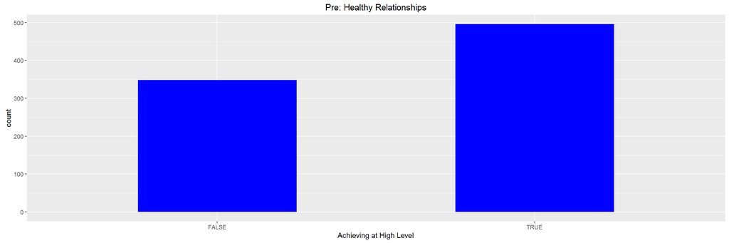

### Healthy Relationships Outcome Distribution Plots

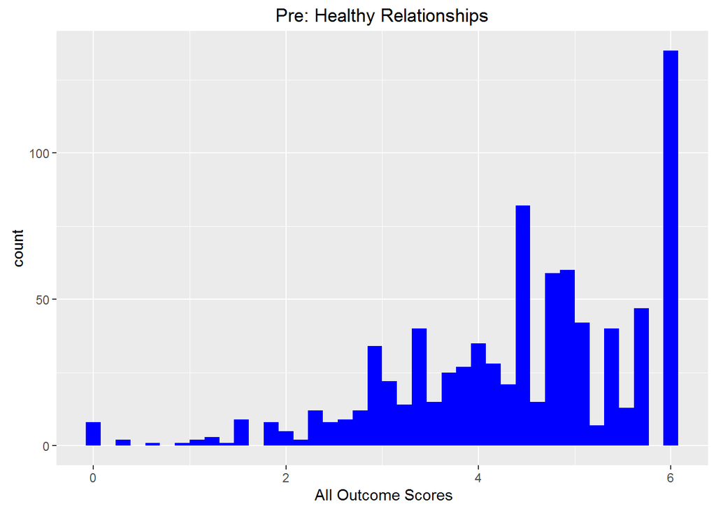

### Pre Survey Healthy Relationship Trends from 2013-2015

Pre survey average scores are down this year along with the proportion of students achieving the outcome at a high level. The key for this analysis is the percent of students increasing their outcome score.

| Year | population | mean | sd | percent achieved |
| --- | --- | --- | --- | --- |
| 2013 | 699 | 4.55 | 1.19 | 60.94% |
| 2014 | 1186 | 4.44 | 1.5 | 60.54% |
| 2015 | 844 | 4.419 | 1.248 | 58.77% |

### Healthy Relationship Time Series

The number of student survey records that could be matched from last year is **63**. Last year students who participated for multiple years had higher healthy relationship scores than students who had not participated in the program before. This is not the case this year.

Healthy Relationship scores regressed from the post survey and students in the program did not score better than students in the program in terms of average scores or proportion of students achieving the skill at a high level.

The number of matched student is **63**, and the number of non matched students is **781**.

| Time | Mean | SD | Achieved | Percent Achieved |
| --- | --- | --- | --- | --- |
| Matched: Post 2014-2015 | 4.613 | 1.055 | 48 | 76.19% |
| Matched: Pre 2015-2016 | 4.426 | 1.294 | 32 | 50.79% |
| Non-Matched: Pre 2015-2016 | 4.418 | 1.245 | 464 | 59.41% |

## Academic Engagement

### Percent of students achieving at a high level:

Academic Engagement questions gauge tangible behaviors that help students succeed in school.The number of valid survey entries is **844** The percent of students achieving the academic achievement at a high skill level is **40.64%**.

### Academic Engagment Outcome Plots

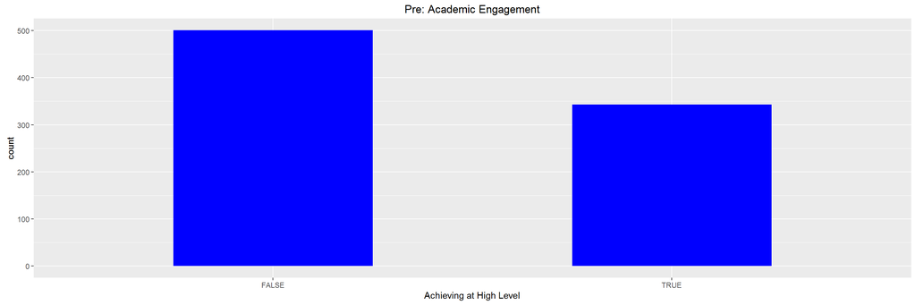

### Academic Engagement Distribution Plots

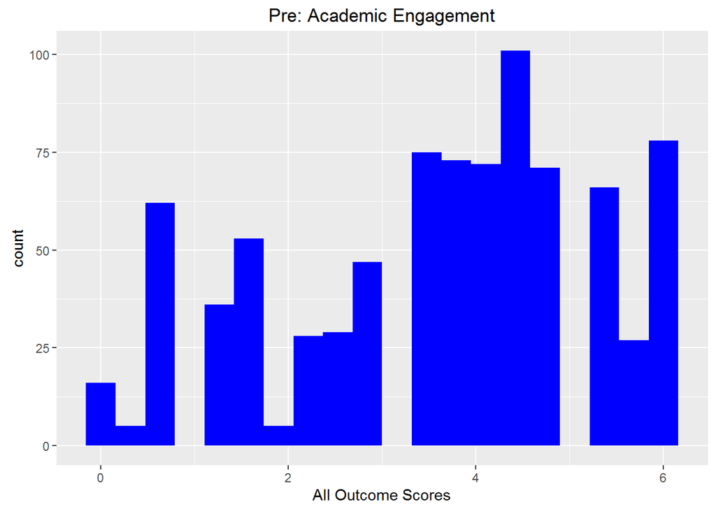

### Academic Engagement Trends from 2013-2015

Pre survey average scores are comparable to last year along with the proportion of students achieving the outcome at a high level. The key for this analysis is the percent of students increasing their outcome score.

| Year | population | mean | sd | percent achieved |
| --- | --- | --- | --- | --- |
| 2013 | 699 | 4.1 | 1.18 | 47.07% |
| 2014 | 1186 | 3.82 | 1.34 | 40.05% |
| 2015 | 844 | 3.612 | 1.648 | 40.64% |

### Academic Engagement Time Series

The number of matched student is **63** and the number of non matched students is **781**.

| Population | Mean | SD | Achieved | Percent Achieved |
| --- | --- | --- | --- | --- |
| Matched: Post 2014-2015 | 4.143 | 0.9196 | 35 | 55.56% |
| Matched: Pre 2015-2016 | 4.012 | 1.228 | 28 | 44.44% |
| Non-Matched: Pre 2015-2016 | 3.58 | 1.674 | 315 | 40.33% |

## Academic Mastery

### Percent of students achieving at a high level

The Academic Mastery questions gauge a student’s attitude towards school and education.The number of valid survey entries is **844**. The percent of students achieving this outcome at a high level is **74.76%**.

### Academic Mastery Outcome Plots

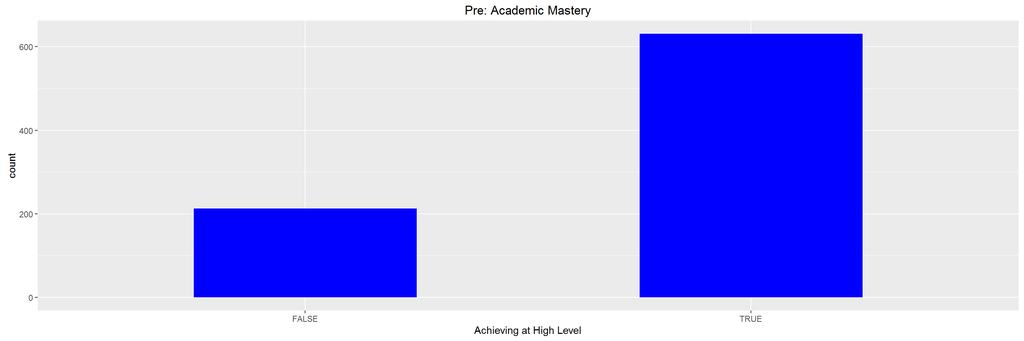

### Academic Mastery Distribution Plots

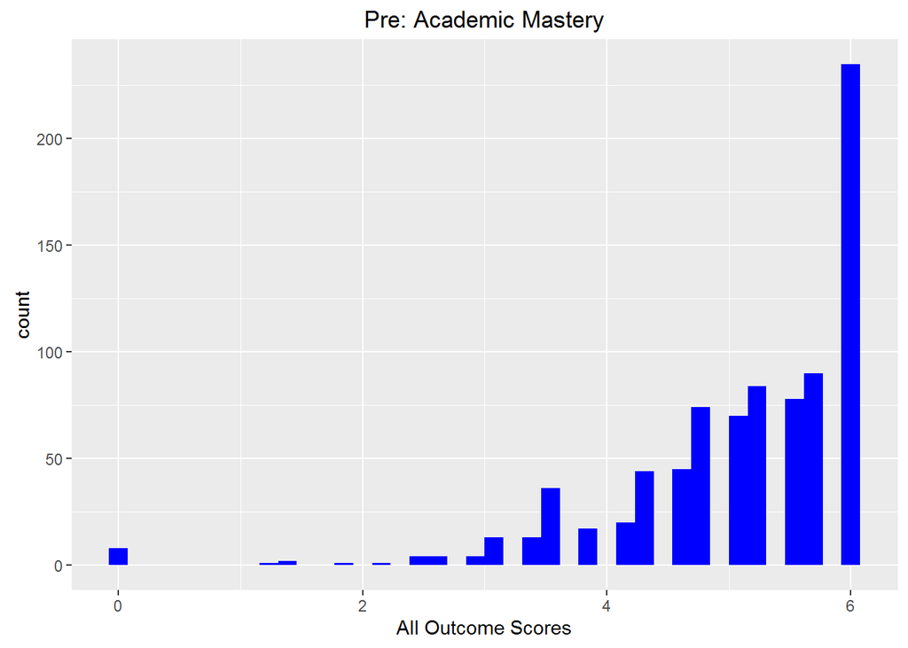

### Academic Mastrey Trends from 2013-2015

Pre survey average scores are comparable to last year along with the proportion of students achieving the outcome at a high level. The key for this analysis is the percent of students maintaining at a high level.

| Year | population | mean | sd | percent achieved |
| --- | --- | --- | --- | --- |
| 2013 | 699 | 5.38 | 0.78 | 85.98% |
| 2014 | 1186 | 5.12 | 0.95 | 76.98% |
| 2015 | 844 | 5.102 | 1.006 | 74.76% |

The table below illustrates that the students who participated in the program last year increased from the post survey and outperformed students who were not in the program last year in both average scores and proportion of achieving the skill at a high level. The difference is statistically significant at the .05 level using a Wilcoxon Signed rank test.

The number of matched student is **63** and the number of non matched students is **781**.

### Academic Mastery Time Series Data

| Population | Mean | SD | Achieved | Percent Achieved |
| --- | --- | --- | --- | --- |
| Matched: Post 2014-2015 | 5.177 | 0.813 | 55 | 87.3% |
| Matched: Pre 2015-2016 | 5.444 | 0.6347 | 56 | 88.89% |
| Non-Matched: Pre 2015-2016 | 5.075 | 1.026 | 575 | 73.62% |

#### Wilcox Test: Compare students in the program Pre and Post Surveys

```
    Wilcoxon signed rank test with continuity correction

data:  post_merge$am.avg.y and post_merge$am.avg.x
V = 902, p-value = 0.01055
alternative hypothesis: true location shift is not equal to 0
```

#### Wilcox Test: Compare students in the program last year and those not in the program last year

```
    Wilcoxon rank sum test with continuity correction

data:  post_merge$am.avg.y and non_match$am.avg
W = 29570, p-value = 0.006842
alternative hypothesis: true location shift is not equal to 0
```